# Analysis of impact of severe weather events on population health and economic consequences

Amir Manafpour

May 21, 2018

## Synopsis

This study represents the most damaging weather events based on the dataset provided by U.S. National Oceanic and Atmospheric Administration’s (NOAA) storm database. The same event types had similar but mismatching names and so the data processing of this study invovled combining and aggregating the same event types with different names. The graphs at the end of this article represent the top 10 event types for the number of injuries/fatalities as well as the amount of economical damage that resulted from each event type. The graphs show that Tornados cause the most amount of injuries/fatailities (several times that of the next event type “Wind”). Also, Floods were found to cause the most amount of economical damage compared to all other event types.

## Data Processing

The data loading process below assumes that the raw zipped data file “repdata%2Fdata%2FStormData.csv.bz2” exists in a folder called “Data Files” in the current working directory.

```r
setwd("C:/Users/amirman121/Documents/Coursera/RepData")
mydata <- read.csv("./Data Files/repdata%2Fdata%2FStormData.csv.bz2")
```

There are several similar categories for event types and so they have been aggregated as follows:

“HEAT”: ALL EVTYPES CONTAINING THE WORD “HEAT”

“TORNADO”: ALL EVTYPES CONTAINING THE WORD “TORNADO”

“HURRICANE”: ALL EVTYPES CONTAINING THE WORD “HURRICANE”

“LIGHTNING”: ALL EVTYPES CONTAINING THE WORD “LIGHTNING”

“HAIL”: ALL EVTYPES CONTAINING THE WORD “HAIL”

“WIND”: ALL EVTYPES CONTAINING THE WORD “WIND”

“ICE/SNOW”: ALL EVTYPES CONTAINING THE WORD “ICE” OR “SNOW” OR “WINTER”

“FLOOD”: ALL EVTYPES CONTAINING THE WORD “FLOOD”

“STORM”: ALL EVTYPES CONTAINING THE WORD “STORM”

```r
#First combine similar categories into one
mydata$EVTYPE <- as.character(mydata$EVTYPE)
condenseddata <- mydata %>%
  mutate(EVTYPE = ifelse(grepl("\\bheat\\b", EVTYPE, ignore.case = TRUE), "HEAT", EVTYPE)) %>%
  mutate(EVTYPE = ifelse(grepl("\\btornado\\b", EVTYPE, ignore.case = TRUE), "TORNADO", EVTYPE)) %>%
  mutate(EVTYPE = ifelse(grepl("\\bhurricane\\b", EVTYPE, ignore.case = TRUE), "HURRICANE", EVTYPE)) %>%
  mutate(EVTYPE = ifelse(grepl("\\bcurrent\\b", EVTYPE, ignore.case = TRUE), "CURRENT", EVTYPE)) %>%
  mutate(EVTYPE = ifelse(grepl("\\blightning\\b", EVTYPE, ignore.case = TRUE), "LIGHTNING", EVTYPE)) %>%
  mutate(EVTYPE = ifelse(grepl("\\bhail\\b", EVTYPE, ignore.case = TRUE), "HAIL", EVTYPE)) %>%
  mutate(EVTYPE = ifelse(grepl("\\bwind", EVTYPE, ignore.case = TRUE), "WIND", EVTYPE)) %>%
  mutate(EVTYPE = ifelse(grepl("\\bice\\b", EVTYPE, ignore.case = TRUE), "ICE/SNOW", EVTYPE)) %>%
  mutate(EVTYPE = ifelse(grepl("\\bsnow\\b", EVTYPE, ignore.case = TRUE), "ICE/SNOW", EVTYPE)) %>%
  mutate(EVTYPE = ifelse(grepl("\\bwinter\\b", EVTYPE, ignore.case = TRUE), "ICE/SNOW", EVTYPE)) %>%
  mutate(EVTYPE = ifelse(grepl("\\bflood\\b", EVTYPE, ignore.case = TRUE), "FLOOD", EVTYPE)) %>%
  mutate(EVTYPE = ifelse(grepl("\\bstorm\\b", EVTYPE, ignore.case = TRUE), "STORM", EVTYPE))

#Determine total injuries and fatalities per category
casualty_sums <- condenseddata %>%
  group_by(EVTYPE) %>%
  summarize(total_injuries = sum(INJURIES), total_fatalities = sum(FATALITIES))

#Determine top 10 categories for injuries and fatalitites
sorted_byinjury <- casualty_sums %>% arrange(desc(total_injuries))
sorted_byfatality <- casualty_sums %>% arrange(desc(total_fatalities))

top10injuries <- sorted_byinjury$EVTYPE[1:10]
top10fatalities <- sorted_byfatality$EVTYPE[1:10]
top10both <- unique(c(as.character(top10fatalities), as.character(top10injuries)))

injfatSubset <- casualty_sums[which(casualty_sums$EVTYPE %in% top10both),]
injfatSubsetMelt <- melt(injfatSubset)
#Generate cash values and Calculate total cash damage
returnCash <- function(dmg, exp){
  cash <- as.numeric(dmg)
  cash[exp=="1"] <- 10 * cash[exp=="1"]
  cash[exp=="2"] <- 10^2 * cash[exp=="2"]
  cash[exp=="3"] <- 10^3 * cash[exp=="3"]
  cash[exp=="4"] <- 10^4 * cash[exp=="4"]
  cash[exp=="5"] <- 10^5 * cash[exp=="5"]
  cash[exp=="6"] <- 10^6 * cash[exp=="6"]
  cash[exp=="7"] <- 10^7 * cash[exp=="7"]
  cash[exp=="8"] <- 10^8 * cash[exp=="8"]
  cash[exp=="B"] <- 10^9 * cash[exp=="B"]
  cash[exp=="h"] <- 100 * cash[exp=="h"]
  cash[exp=="H"] <- 100 * cash[exp=="H"]
  cash[exp=="K"] <- 1000 * cash[exp=="K"]
  cash[exp=="m"] <- 10^6 * cash[exp=="m"]
  cash[exp=="M"] <- 10^6 * cash[exp=="M"]
  return(cash)
}

condenseddata$TOTCASH <- with(condenseddata, returnCash(PROPDMG, PROPDMGEXP) + returnCash(CROPDMG, CROPDMGEXP))

#Determine total cash damage per category
totcash_sums <- condenseddata %>%
  group_by(EVTYPE) %>%
  summarize(sumTotalCash = sum(TOTCASH))

#Determine top 10 total cash damage categories
sorted_bycashdmg <- totcash_sums %>% arrange(desc(sumTotalCash))

top10cashdmg <- sorted_bycashdmg$EVTYPE[1:10]

cashSubset <- totcash_sums[which(totcash_sums$EVTYPE %in% top10cashdmg),]
cashSubsetMelt <- melt(cashSubset)
```

## Results

The top 10 categories were used to represent the data for each of the graphs below.

2- Floods caused the most amount of economical damage compared to any other type of weather event as shown in the 2nd graph below.

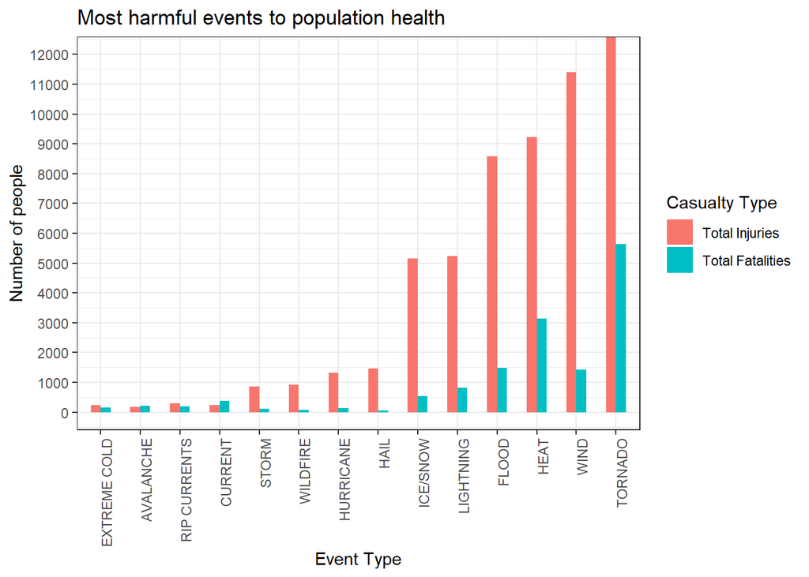

```r
#Plot total injuries and fatalities per modified category type
ggplot(injfatSubsetMelt, aes(x = reorder(EVTYPE, value), y= value, fill = variable), xlab="Event Type") +
  geom_bar(stat="identity", width=.5, position = "dodge") +
  coord_cartesian(ylim=c(0, 12000)) +
  ggtitle("Most harmful events to population health") +
  ylab("Number of people") +
  xlab("Event Type") +
  scale_fill_discrete(name = "Casualty Type", labels = c("Total Injuries", "Total Fatalities")) +
  theme_bw() +
  theme(axis.text.x = element_text(angle = 90, hjust = 1)) +
  scale_y_continuous(breaks = seq(0,12000,1000))
```

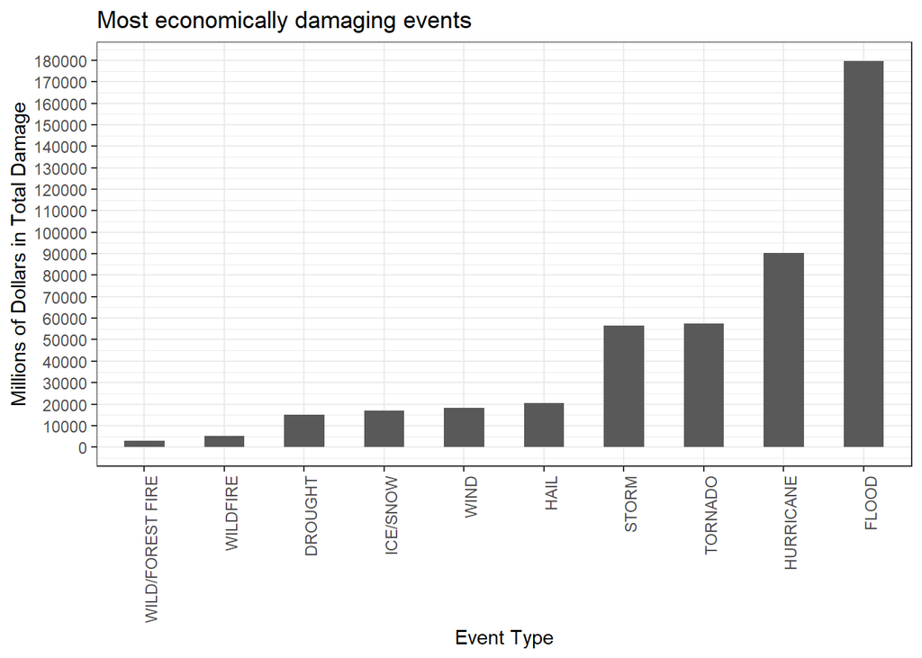

```r
ggplot(cashSubsetMelt, aes(x = reorder(EVTYPE, value), y= value/(10^6)), xlab="Event Type") +
  geom_bar(stat="identity", width=.5, position = "dodge") +
  #coord_cartesian(ylim=c(0, 12000)) +
  ggtitle("Most economically damaging events") +
  ylab("Millions of Dollars in Total Damage") +
  xlab("Event Type") +
  theme_bw() +
  theme(axis.text.x = element_text(angle = 90, hjust = 1)) +
  scale_y_continuous(breaks = seq(0,250000,10000))
```